# degree-adverbs

erin

11/12/2014

# Intensity of degree adverbs

Hypothesis: adverbs of degree, like “somewhat” and “extremely”, modify the adjectives they describe in proportion to the cost of uttering them. For example, if “inordinately” is more costly to utter than “very”, the former will have a stronger meaning than the latter.

This cost might manifest in syllable length or in surprisal (how unlikely is that word to be said?).

## Experiment 1: intensifiers

I use Google Ngrams data to get the surprisal of various intensifying degree adverbs and recorded their syllable lengths.

```
##          ngram frequency syllables
## 1  exceedingly    977435         4
## 2  excessively    877280         4
## 3       really 148918637         2
## 4   enormously   1011751         4
## 5       hugely   1074430         2
## 6        crazy  13048828         2
## 7     insanely    359644         3
## 8       wildly   1414395         3
## 9        super  16902202         2
## 10    horribly    819111         3
## 11   extremely  21862963         3
## 12        very 292897993         2
## 13      vastly   1311113         2
## 14       quite  55269390         1
## 15    terribly   1906059         3
## 16  uncommonly    135747         4
## 17    slightly  28523541         2
## 18    somewhat  14075405         2
## 19  moderately   1922506         4
## 20       a bit  33634149         2
## 21       a tad    775965         2
## 22     sort of  19227411         2
## 23     kind of  43691232         2
```

I ran an experiment asking participants the prices of different “*[adverb]* expensive” watches, laptops, and coffee makers. Prices were elicited with free response, and trials looked like this:

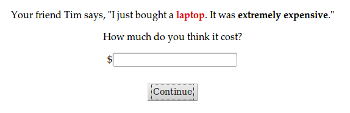

In a simple ANOVA, participant (`workerid`) predicted responses better than item and intensifier.

```
## Analysis of Variance Table
##
## Response: price
##                            Df   Sum Sq  Mean Sq F value Pr(>F)
## intensifier                15 4.27e+10 2.85e+09    0.56 0.9020
## item                        2 1.15e+10 5.75e+09    1.14 0.3207
## workerid                   39 3.64e+11 9.33e+09    1.85 0.0017 **
## intensifier:item           30 1.09e+11 3.64e+09    0.72 0.8614
## intensifier:workerid      585 1.60e+12 2.74e+09    0.54 1.0000
## item:workerid              78 2.21e+11 2.84e+09    0.56 0.9989
## intensifier:item:workerid 626 9.48e+11 1.51e+09    0.30 1.0000
## Residuals                 544 2.74e+12 5.04e+09
## ---
## Signif. codes:  0 '***' 0.001 '**' 0.01 '*' 0.05 '.' 0.1 ' ' 1
```

Surprisal was not a significant predictor of response.

```
##
## Call:
## lm(formula = price ~ surprisal, data = intensifiers)
##
## Residuals:
##     Min      1Q  Median      3Q     Max
##   -4905   -3509   -2371   -1105 2296032
##
## Coefficients:
##             Estimate Std. Error t value Pr(>|t|)
## (Intercept)    -3744       7502   -0.50     0.62
## surprisal        549        590    0.93     0.35
##
## Residual standard error: 56100 on 1918 degrees of freedom
## Multiple R-squared:  0.000451,   Adjusted R-squared:  -7.02e-05
## F-statistic: 0.865 on 1 and 1918 DF,  p-value: 0.352
```

This probably has something to do with the fact that some participants gave answers that were insanely high.

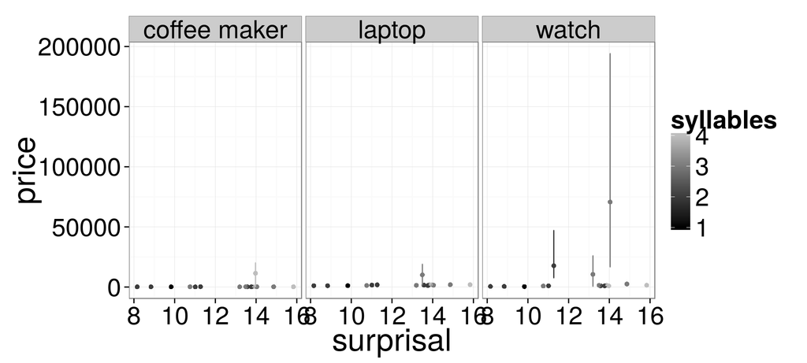

I ran a mixed effect model, which found no significant effect of surprisal on response.

```
## Linear mixed model fit by REML ['lmerMod']
## Formula: price ~ (surprisal) + (1 | item) + (1 | workerid) + (surprisal |
##     workerid) + (surprisal | item)
##    Data: intensifiers
##
## REML criterion at convergence: 47352
##
## Scaled residuals:
##    Min     1Q Median     3Q    Max
##  -2.05  -0.03  -0.01   0.01  40.51
##
## Random effects:
##  Groups     Name        Variance Std.Dev. Corr
##  workerid   (Intercept) 4.10e+08 20254
##             surprisal   6.64e+06  2577    -1.00
##  workerid.1 (Intercept) 0.00e+00     0
##  item       (Intercept) 1.76e+07  4191
##             surprisal   2.43e+05   493    -1.00
##  item.1     (Intercept) 0.00e+00     0
##  Residual               2.97e+09 54539
## Number of obs: 1920, groups:  workerid, 40; item, 3
##
## Fixed effects:
##             Estimate Std. Error t value
## (Intercept)    -3680       8324   -0.44
## surprisal        544        759    0.72
##
## Correlation of Fixed Effects:
##           (Intr)
## surprisal -0.968
```

In a similar mixed effect model, there is not significant effect of syllables on response.

```
## Linear mixed model fit by REML ['lmerMod']
## Formula: price ~ (syllables) + (1 | item) + (1 | workerid) + (syllables |
##     workerid) + (syllables | item)
##    Data: intensifiers
##
## REML criterion at convergence: 47364
##
## Scaled residuals:
##    Min     1Q Median     3Q    Max
##  -1.58  -0.03  -0.01   0.00  40.69
##
## Random effects:
##  Groups     Name        Variance Std.Dev. Corr
##  workerid   (Intercept) 6.30e+06  2511
##             syllables   1.11e+07  3329    1.00
##  workerid.1 (Intercept) 0.00e+00     0
##  item       (Intercept) 1.38e+06  1175
##             syllables   3.48e+04   186    1.00
##  item.1     (Intercept) 0.00e+00     0
##  Residual               3.01e+09 54828
## Number of obs: 1920, groups:  workerid, 40; item, 3
##
## Fixed effects:
##             Estimate Std. Error t value
## (Intercept)     1006       4094    0.25
## syllables        775       1489    0.52
##
## Correlation of Fixed Effects:
##           (Intr)
## syllables -0.823
```

When I incorporate surprisal and syllables both as fixed effects, I again find no significant effect of either.

```
## Linear mixed model fit by REML ['lmerMod']
## Formula: price ~ (surprisal + syllables) + (1 | item) + (1 | workerid) +
##     (surprisal + syllables | workerid) + (surprisal + syllables |
##     item)
##    Data: intensifiers
##
## REML criterion at convergence: 47334
##
## Scaled residuals:
##    Min     1Q Median     3Q    Max
##  -2.01  -0.03   0.00   0.01  40.48
##
## Random effects:
##  Groups     Name        Variance Std.Dev. Corr
##  workerid   (Intercept) 4.59e+08 2.14e+04
##             surprisal   8.96e+06 2.99e+03 -1.00
##             syllables   2.17e+06 1.47e+03  1.00 -1.00
##  workerid.1 (Intercept) 8.13e-01 9.02e-01
##  item       (Intercept) 2.30e+07 4.79e+03
##             surprisal   6.14e+05 7.84e+02 -1.00
##             syllables   1.17e+06 1.08e+03  1.00 -1.00
##  item.1     (Intercept) 0.00e+00 0.00e+00
##  Residual               2.97e+09 5.45e+04
## Number of obs: 1920, groups:  workerid, 40; item, 3
##
## Fixed effects:
##             Estimate Std. Error t value
## (Intercept)    -3822       8635   -0.44
## surprisal        602       1021    0.59
## syllables       -208       2000   -0.10
##
## Correlation of Fixed Effects:
##           (Intr) srprsl
## surprisal -0.882
## syllables  0.309 -0.685
```

However, if I clean up the data and incorporate another source of information, I do find a significant positive effect of surprisal in an ANOVA.

```
##
## Call:
## lm(formula = sdzprice ~ surprisal, data = intensifiers)
##
## Residuals:
##    Min     1Q Median     3Q    Max
## -2.370 -0.673 -0.284  0.493  6.799
##
## Coefficients:
##             Estimate Std. Error t value Pr(>|t|)
## (Intercept)  -1.2221     0.1293   -9.45   <2e-16 ***
## surprisal     0.0976     0.0102    9.59   <2e-16 ***
## ---
## Signif. codes:  0 '***' 0.001 '**' 0.01 '*' 0.05 '.' 0.1 ' ' 1
##
## Residual standard error: 0.967 on 1918 degrees of freedom
## Multiple R-squared:  0.0458, Adjusted R-squared:  0.0453
## F-statistic:   92 on 1 and 1918 DF,  p-value: <2e-16
```

First, I used Justine’s human priors data to subtract out the mean and divide by the standard deviation for each item (it seems reasonable to assume that items with more variation in their prices will have larger jumps between “very” and “inordinately” expensive). Then, because I have a response from every participant for every pair of item and intensifier, I z-scored participants’ responses. This does not fully standardize responses, but it comes closer.

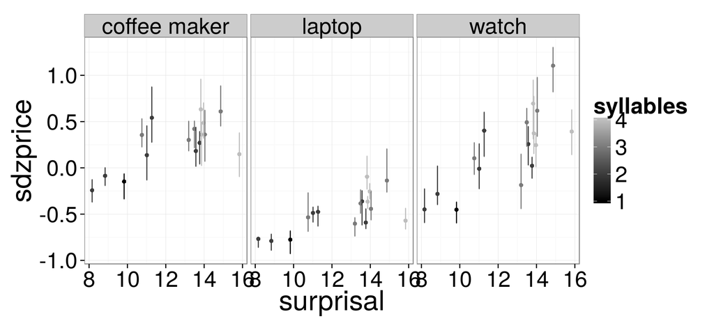

Additionally, incorporating prior elicitation from Justine’s experiment and then z-scoring by participant shows a significant effect of syllables above and beyond the effect of surprisal and an interaction between the two costs.

```
##
## Call:
## lm(formula = sdzprice ~ surprisal * syllables, data = intensifiers)
##
## Residuals:
##    Min     1Q Median     3Q    Max
## -2.228 -0.670 -0.269  0.515  6.809
##
## Coefficients:
##                     Estimate Std. Error t value Pr(>|t|)
## (Intercept)          -2.5972     0.4539   -5.72  1.2e-08 ***
## surprisal             0.1884     0.0371    5.08  4.2e-07 ***
## syllables             0.7187     0.1946    3.69  0.00023 ***
## surprisal:syllables  -0.0486     0.0147   -3.32  0.00093 ***
## ---
## Signif. codes:  0 '***' 0.001 '**' 0.01 '*' 0.05 '.' 0.1 ' ' 1
##
## Residual standard error: 0.963 on 1916 degrees of freedom
## Multiple R-squared:  0.0543, Adjusted R-squared:  0.0528
## F-statistic: 36.6 on 3 and 1916 DF,  p-value: <2e-16
```

So it seems like there is some relationship between the cost of an intensifier and its strength.

I was concerned that the relationship between surprisal and strength might be an effect of more extreme objects being less common and therefore talked about less, which would result in words that describe those objects being rarer. So I ran Experiment 2 to test that hypothesis.

## Experiment 2: deintensifiers

Experiment 2 tests a competing hypothesis that might explain some of the data in Experiment 1.

Supposed that objects that are more extreme along a scale are less common and therefore talked about less. Then words that describe them (adverbs of degree that are quite strong) would be more rare. Thus the surprisal at these words would be a consequenct of their meaning rather than a cause. Were this the case, then stronger *deintensifying* adverbs of degree (e.g. “somewhat” or “moderately”) would be more common because they describe more typical items that are more moderate along a scale.

I found no evidence for the competing hypothesis (that stronger deintensifying adverbs of degree are more common). I also did not find evidence that stronger deintensifying degree adverbs are rarer.

```
##
## Call:
## lm(formula = sdzprice ~ surprisal * syllables, data = deintensifiers)
##
## Residuals:
##    Min     1Q Median     3Q    Max
## -2.379 -0.714 -0.226  0.614  3.361
##
## Coefficients: (1 not defined because of singularities)
##                     Estimate Std. Error t value Pr(>|t|)
## (Intercept)           0.3704     0.4471    0.83     0.41
## surprisal             0.0251     0.0235    1.07     0.29
## syllables             0.0162     0.0486    0.33     0.74
## surprisal:syllables       NA         NA      NA       NA
##
## Residual standard error: 0.982 on 1117 degrees of freedom
## Multiple R-squared:  0.00188,    Adjusted R-squared:  9.76e-05
## F-statistic: 1.05 on 2 and 1117 DF,  p-value: 0.349
```

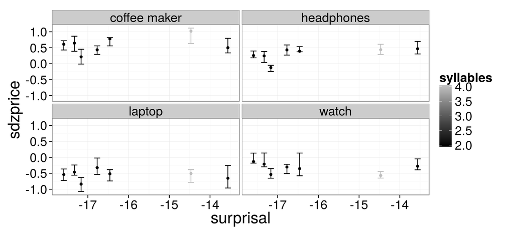

## Experiment 3:

In Experiment 3, I tried to replicate my findings from Experiment 1 (that stronger intensifying degree adverbs happen to have higher costs) and from Experiment 2 (that stronger deintensifying adverbs are not necessarily more common). This time I tested all participants on all combinations of item and adverb, where adverbs were either intensifying or deintensifying degree adverbs. I only ran this experiment on 10 participants.

I found only a marginal effect of surprisal.

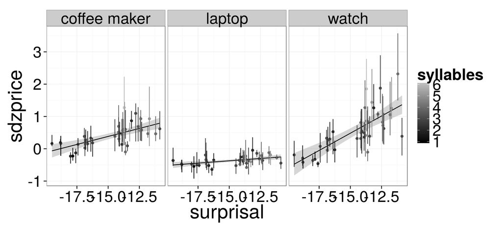

```
##
## Call:
## lm(formula = sdzprice ~ surprisal * syllables, data = intensifiers)
##
## Residuals:
##    Min     1Q Median     3Q    Max
## -1.885 -0.671 -0.266  0.391  5.634
##
## Coefficients:
##                     Estimate Std. Error t value Pr(>|t|)
## (Intercept)          0.96332    0.67323    1.43    0.153
## surprisal            0.07193    0.04325    1.66    0.097 .
## syllables            0.15853    0.23394    0.68    0.498
## surprisal:syllables  0.00436    0.01638    0.27    0.790
## ---
## Signif. codes:  0 '***' 0.001 '**' 0.01 '*' 0.05 '.' 0.1 ' ' 1
##
## Residual standard error: 1.02 on 1136 degrees of freedom
## Multiple R-squared:  0.0673, Adjusted R-squared:  0.0648
## F-statistic: 27.3 on 3 and 1136 DF,  p-value: <2e-16
```

I found a marginally significant negative effect of surprisal in the deintensifiers condition, which provides evidence for more costly deintensifying adverbs referring to consequently lower prices. However, in direct contrast to that, syllable length appears to predict more expensive prices.

```
## facet_wrap(item)
```

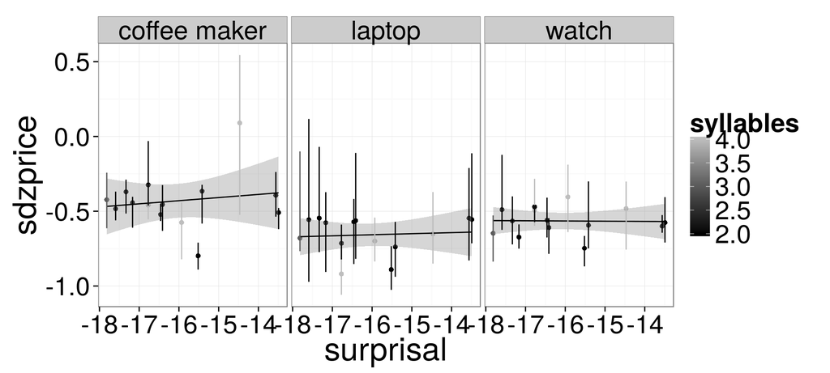

```
##
## Call:
## lm(formula = sdzprice ~ surprisal * syllables, data = deintensifiers)
##
## Residuals:
##    Min     1Q Median     3Q    Max
## -1.313 -0.229 -0.058  0.130  5.523
##
## Coefficients:
##                     Estimate Std. Error t value Pr(>|t|)
## (Intercept)          -2.6578     1.0967   -2.42    0.016 *
## surprisal            -0.1297     0.0690   -1.88    0.061 .
## syllables             0.9525     0.4471    2.13    0.034 *
## surprisal:syllables   0.0587     0.0282    2.09    0.038 *
## ---
## Signif. codes:  0 '***' 0.001 '**' 0.01 '*' 0.05 '.' 0.1 ' ' 1
##
## Residual standard error: 0.524 on 416 degrees of freedom
## Multiple R-squared:  0.0121, Adjusted R-squared:  0.00495
## F-statistic: 1.69 on 3 and 416 DF,  p-value: 0.168
```